# Classical and Positivist Schools of Criminology

CRIM 104

## Warning

[video not shown]

# The Classical School

## The Classical School in brief

- An 18th century movement of reform that favored legislating of a balanced criminal code of law
- Developed the first organized thoughts on crime, criminals and criminal justice
- Influenced by events in European culture and society (1500s-1700s)
- Major contributors
  - Cesare Beccaria (1738-1794)
  - Jeremy Bentham (1748-1832)

## Social context of the Classical School

- Diminished power of the aristocracy & Church
- Rising middle class, mercantilism & industrial revolution
- Exploration of humanity
- Capricious and cruel criminal justice system

## Intellectual context of the CLassical School

- Humanist philosophy – all men were free and had natural rights
- Philosophy of social justice
- Critique of harsh & barbaric government
- Reforms encouraged
- Education & enlightenment (belief in power of human reason – logic )

## Important features

- Not really a theory of crime causation
- Focused on how to address crime
  - Punishment should be just, fair, proportionate & less cruel
  - Laws should be clear and impartial, equitable with less discretion

# Guiding premises of the Classical School

## Free will

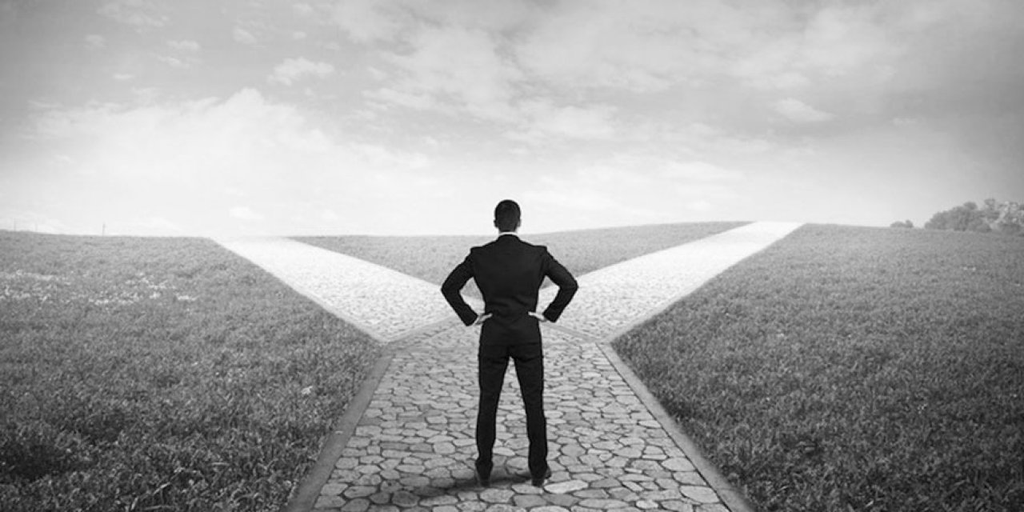

## Hedonism

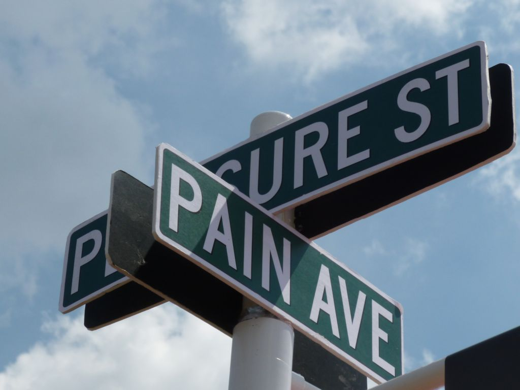

## Rational punishment rather than revenge

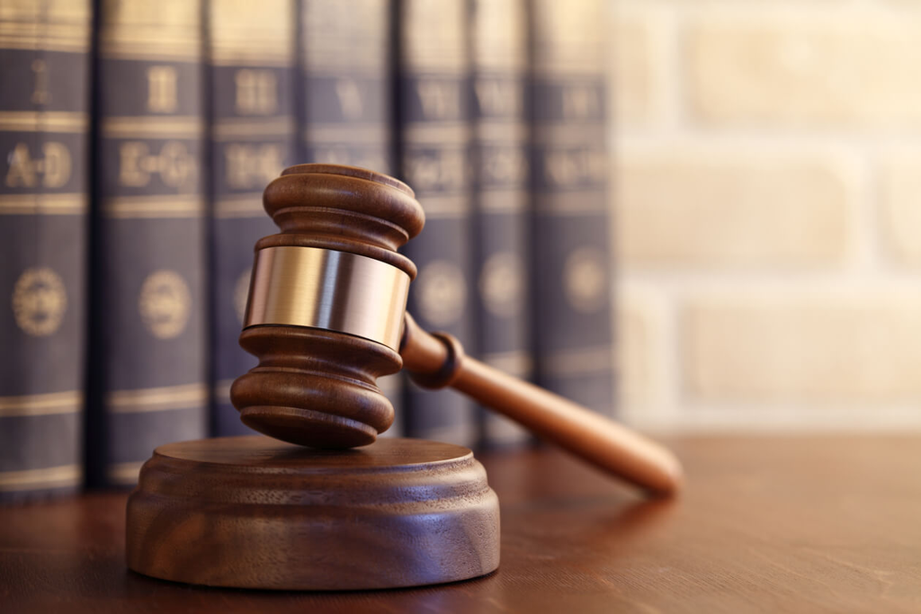

## Utilitarianism

[figure not shown]

## Due process

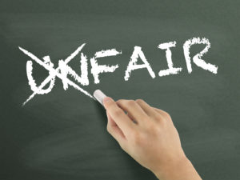

## Social contract

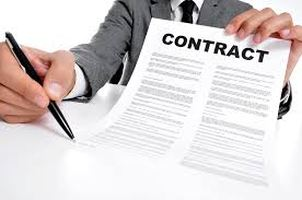

## Social contract

- A political philosophy to justify government
- A contract that exists between the state & its citizens
- State exists to serve the citizens
- State can only exercise authority granted by citizens
- Individuals surrender to the state only the limited rights necessary to ensure protection of all citizens
- Life cannot be surrendered

## Deterrence

[figure not shown]

## Forms of deterrence

- Specific deterrence
  - Legal punishment given directly to offender
  - Designed to remove gains
  - Individual assesses lack of gain & decides not to repeat similar acts
- General deterrence
  - Others aware of an individual being punished
  - Realize no gains from violation of law
  - Assumes public nature of punishment

## Elements of deterrence

- Celerity: Speed with which punishment is applied after act occurs
- Certainty: Likelihood of being caught and punishment being applied
- Severity: Amount or degree of punishment, relative to the act

# Positivist School of Criminology

## Positivism

- Not a theory but a philosophy
  - Use of science in regulating the world
- Basic features
  - Systematic observation
  - Accumulation of evidence
  - Objective fact
  - Deductive framework

## The Positivist School in brief

- First scientific perspective on crime & criminals
- Emphasis on empiricism and valued scientific expertise
- Determinism

## Positive School Influences

- Rise of science as influential form of knowledge
- The work of Darwin in evolution & social Darwinism
- Cartographics and “social statistics”
- Anthropological evidence from “primitive” peoples
- Idea of perfecting humankind through science

## Early Biological Positivism

- Physiognomy
  - Body characteristics assumed related to behavior
- Phrenology
  - Head structure (“bumps on the head”)
  - Assumed related to behavior

## Main Contributors

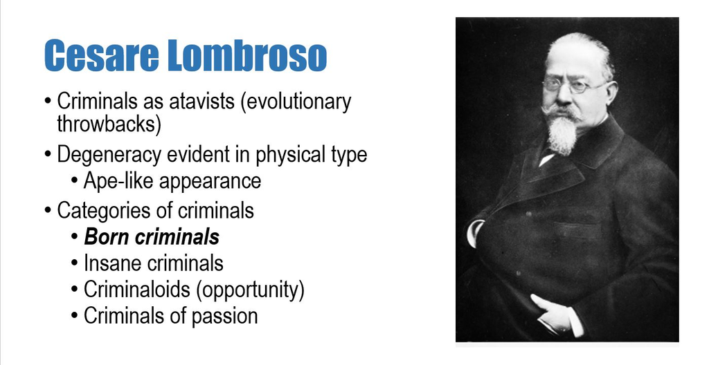

## Main Contributors

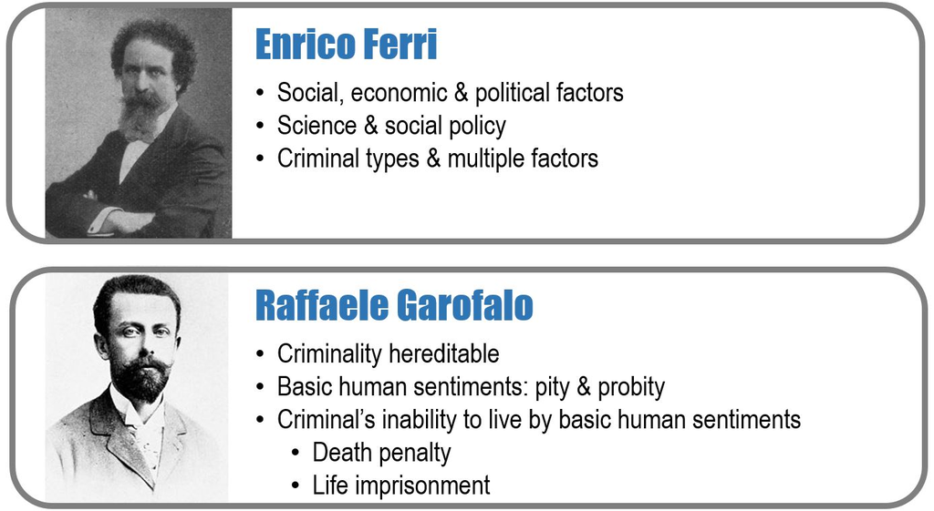

## Research on the physical features of criminals

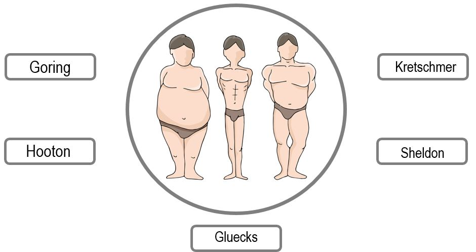

## Psychogenic Causes of Crime

[figure not shown]

## Eugenics and Psychological Movements

- Popular ideas spread from biological work:
  - Dangerous classes
  - Criminals are degenerates
- Eugenics movement spread from atavist concept
- Studies used cases where criminal lineage was traced
  - Dugdale: The Jukes, 1877
  - Goddard: The Kallikaks, 1912

# Modern biological approaches

## Current biological approach

[video not shown]

## Evolution of biological approaches

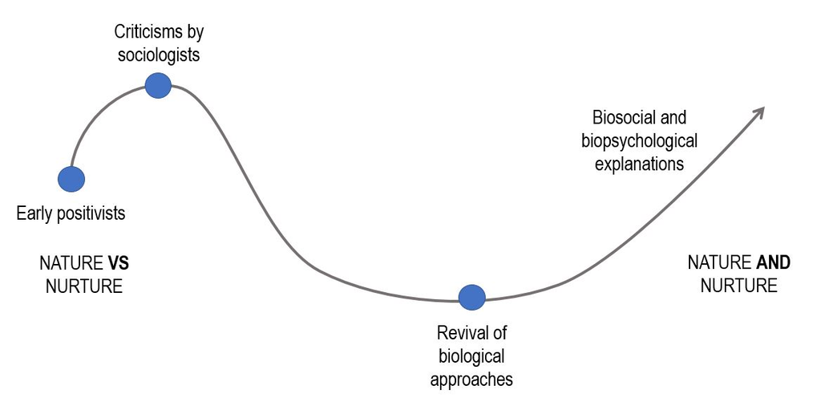

## Twin and adoption studies

[figure not shown]

## Brain chemestry

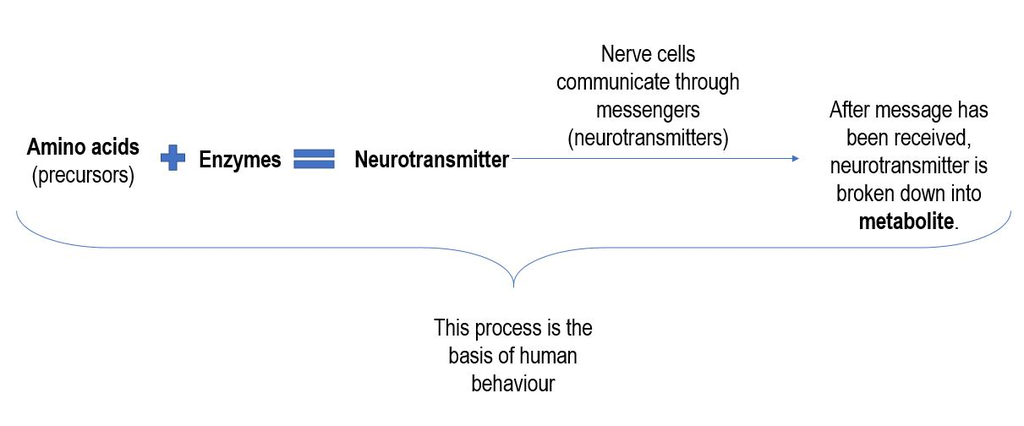

# Anomie Theory

- French philosopher
- Sociology was new, positivist field
- Social structure and social determinism
- Individual as product of the society
- Saw society as evolving
  - After French revolution–rapid industrialization

## Agrarian society

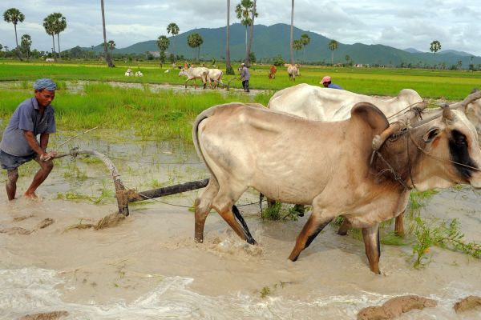

## Industrialized society

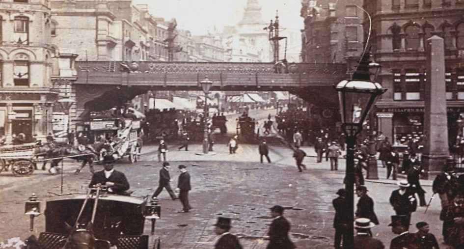

## Durkheim’s Perspective

- Society’s evolution: from mechanical solidarity to organic solidarity
- Evolution destabilizes equilibrium
- Organic societies have continual state of anomie (lawlessness)
- Balance forces integration and forces of regulation = balance

## Durkheim’s view on crime

- Crime is normal, serves function of helping society develop order
- Punishment necessary to ensure protection of norms, maintains social solidarity
- Focus on social conditions where rules lose value
- Without a regulated society as a guide, individuals are confused & can’t adjust; this is anomie

# Anomie-strain theory

## Anomie-strain theory in brief

- Robert Merton (1938)
- Focused on social structure & cultural disparities in American society
- Studied relationship between social structure and opportunity, particularly for African Americans
- Saw strain from social disjunction between goals and means of society
  - Goals: what one should strive for (money, success, status)
  - Means: ways of attaining goals (approved and not)

## Modes of adaptation to strain

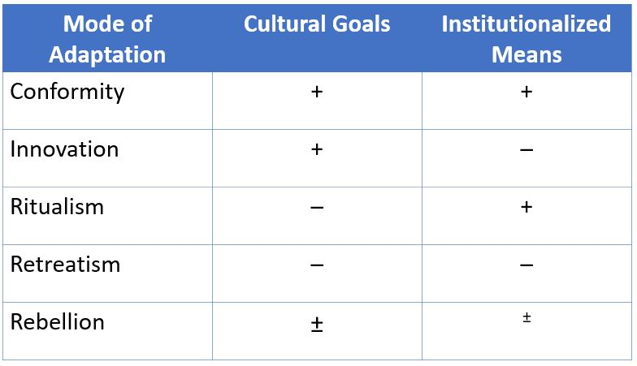

## Main influences

- Conditions produced by Great Depression
- Govt. response: change social structure, create work programs, create and collect social data
- Durkheim and social-structure ideas
- Competition between Chicago School and “East Coast” sociology
- Parson’s grand theory
  - Fit with Durkheim’s structural-functionalist ideas, suggested rates of crime in society need to be explained, not individual crime

# Strain based theories

## General Strain Theory

- Agnew (1985)
- Basic premise:
  - Teens experience other, more immediate sources of strain (appearance, popularity, school, etc)
- Strain experienced by teens
  - Introduction of negative stimuli
  - Removal of positive stimuli
- Strains may lead to frustration, anger, and delinquency

## Institutional Anomie Theory

- Steven Messner and Richard Rosenfeld (1994)
- Main premise:
  - Failure of social institutions (political system, education, family, and the economy) to integrate and regulate the pursuit of goals in a capitalist society
- Institutional imbalance (institutional-anomie), in which the economy dominates political system, education, and the family
  - This leads to an amoral “ends justifies the means” attitude in society

# Summaries

## Classical School

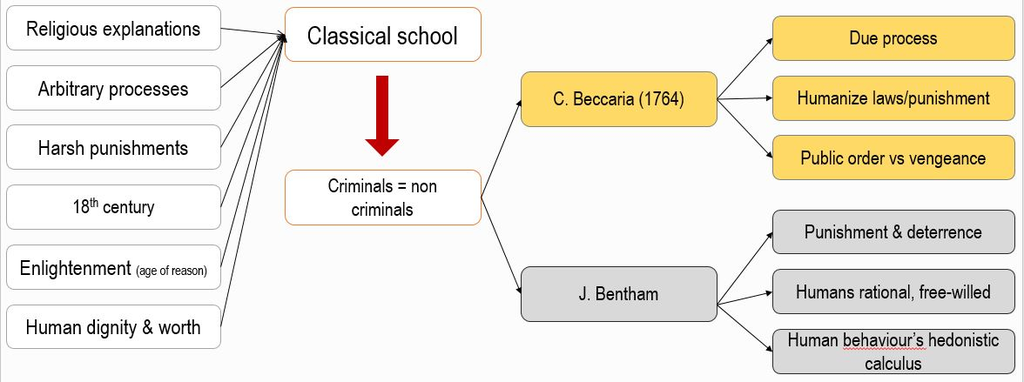

## Positivist School

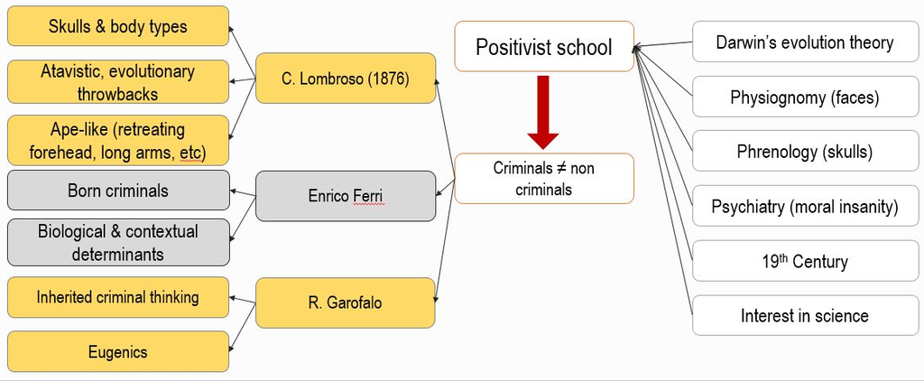

## Emile Durkheim

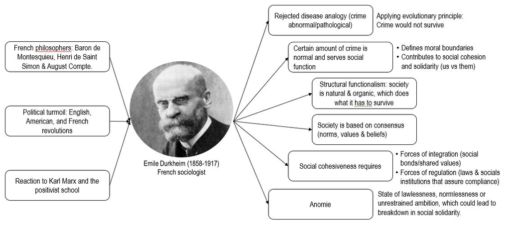

## Anomie Strain Theory

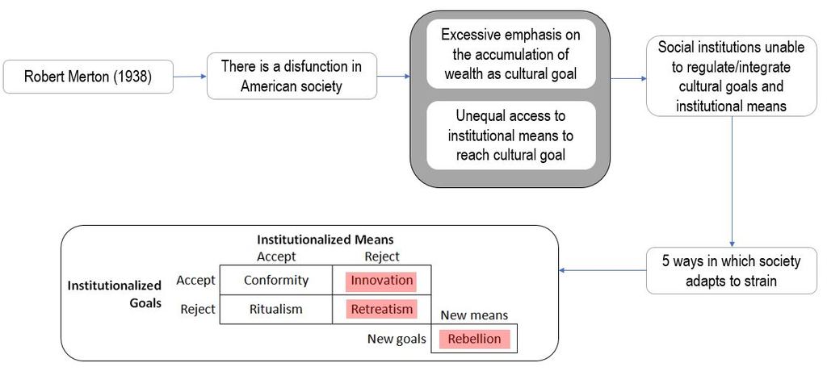

# Important content

## Key concepts and terms

| Free will | Phrenology | Anomie |
| --- | --- | --- |
| Hedonism | Psycoanalysis | Modes of adaptation |
| Utilitarianism | Feebleminded | Retreatism |
| Due process | Atavists | Innovation |
| Social contract | Eugenics | Rebellion |
| Deterrence | Concordance rates | Conformity |
| Positivism | Neurotransmitters | Ritualism |
| Determinism | Forces of regulation |  |
| Physiognomy | Forces of integration |  |